# 1-Imputation_Techniques_ContinuousVariables

## How Data can get Missing?

1. Missing Data Completely at Random : There is no pattern observed for Missing data. Data is randomly missing
2. Missing Data at Random: For example, Data are missing more in case of Men than Women as far age is concerned. Missing data is dependent on other co-variates or other independent variables
3. Missing Data not at Random: The missing data has got systematically introduced in the dataset and the missing data's has direct connection with the target variable.

## Mean and median imputation

Imputation is the act of replacing missing data with statistical estimates of the missing values. The goal of any imputation technique is to produce a **complete dataset** that can then be then used for machine learning.

Mean/median imputation consists of replacing all occurrences of missing values (NA) within a variable by the mean (if the variable has a Gaussian distribution) or median (if the variable has a skewed distribution).

### Assumptions

Mean/median imputation has the assumption that the data are missing completely at random (MCAR). If this is the case, we can think of replacing the NA with the most frequent occurrence of the variable, which is the mean if the variable has a Gaussian distribution, or the median otherwise.

The rationale is to replace the population of missing values with the most frequent value, since this is the most likely occurrence.

### Advantages

- Easy to implement
- Fast way of obtaining complete datasets

### Limitations

- Distortion of original variance
- Distortion of covariance with remaining variables within the dataset

# Random sample imputation

Imputation is the act of replacing missing data with statistical estimates of the missing values. The goal of any imputation technique is to produce a **complete dataset** that can then be then used for machine learning.

Random sampling imputation is in principle similar to mean/median imputation, in the sense that it aims to preserve the statistical parameters of the original variable, for which data is missing.

Random sampling consist of taking a random observation from the pool of available observations of the variable, and using that randomly extracted value to fill the NA. In Random Sampling one takes as many random observations as missing values are present in the variable.

By random sampling observations of the variable for those instances where data is available, we guarantee that the mean and standard deviation of the variable are preserved.

### Assumptions

Random sample imputation assumes that the data are missing completely at random (MCAR). If this is the case, it makes sense to substitute the missing values, by values extracted from the original variable distribution.

From a probabilistic point of view, values that are more frequent (like the mean or the median) will be selected more often (because there are more of them to select from), but other less frequent values will be selected as well. Thus, the variance of the variable is preserved.

The rationale is to replace the population of missing values with a population of values with the same distribution of the variable.

### Advantages

- Easy to implement
- Fast way of obtaining complete datasets
- Preserves the variance of the variable

### Limitations

- Randomness

```python
import pandas as pd
import numpy as np

import matplotlib.pyplot as plt
% matplotlib inline

# for regression problems
from sklearn.linear_model import LinearRegression
from sklearn.ensemble import RandomForestRegressor

# for classification
from sklearn.linear_model import LogisticRegression
from sklearn.ensemble import RandomForestClassifier
from sklearn.svm import SVC

# to split and standarize the datasets
from sklearn.model_selection import train_test_split
from sklearn.preprocessing import StandardScaler

# to evaluate regression models
from sklearn.metrics import mean_squared_error

# to evaluate classification models
from sklearn.metrics import roc_auc_score

import warnings
warnings.filterwarnings('ignore')
```

## Titanic

```python
# load the Titanic Dataset with a few variables for demonstration

data = pd.read_csv('titanic_feature.csv', usecols = ['Age', 'Fare','Survived'])
data.head()
```

|  | Survived | Age | Fare |
| --- | --- | --- | --- |
| 0 | 0 | 22.0 | 7.2500 |
| 1 | 1 | 38.0 | 71.2833 |
| 2 | 1 | 26.0 | 7.9250 |
| 3 | 1 | 35.0 | 53.1000 |
| 4 | 0 | 35.0 | 8.0500 |

```python
# let's look at the percentage of NA

data.isnull().mean()
```

```
Survived    0.000000
Age         0.198653
Fare        0.000000
dtype: float64
```

### Imputation important

Imputation should be done over the training set, and then propagated to the test set. This means that the mean/median to be used to fill missing values both in train and test set, should be extracted from the train set only. And this is to avoid overfitting.

```python
# let's separate into training and testing set

X_train, X_test, y_train, y_test = train_test_split(data, data.Survived, test_size=0.3,
                                                    random_state=0)
X_train.shape, X_test.shape
```

```
((623, 3), (268, 3))
```

```python
# let's make a function to create 2 variables from Age:
# one filling NA with median, and another one filling NA with zeroes

def impute_na(df, variable, median,mean):
    df[variable+'_median'] = df[variable].fillna(median)
    df[variable+'_zero'] = df[variable].fillna(0)
    df[variable+'_mean'] = df[variable].fillna(mean)
    # random sampling
    df[variable+'_random'] = df[variable]
    # extract the random sample to fill the na
    random_sample = X_train[variable].dropna().sample(df[variable].isnull().sum(), random_state=0)
    # pandas needs to have the same index in order to merge datasets
    random_sample.index = df[df[variable].isnull()].index
    df.loc[df[variable].isnull(), variable+'_random'] = random_sample
```

```python
median = X_train.Age.median()
median
```

```
29.0
```

```python
mean = X_train.Age.mean()
mean
```

```
29.915338645418327
```

```python
## Call impute_na function. This function creates 2 new additional variables
impute_na(X_train, 'Age', median,mean)
X_train.head(15)
```

|  | Survived | Age | Fare | Age_median | Age_zero | Age_mean | Age_random |
| --- | --- | --- | --- | --- | --- | --- | --- |
| 857 | 1 | 51.0 | 26.5500 | 51.0 | 51.0 | 51.000000 | 51.0 |
| 52 | 1 | 49.0 | 76.7292 | 49.0 | 49.0 | 49.000000 | 49.0 |
| 386 | 0 | 1.0 | 46.9000 | 1.0 | 1.0 | 1.000000 | 1.0 |
| 124 | 0 | 54.0 | 77.2875 | 54.0 | 54.0 | 54.000000 | 54.0 |
| 578 | 0 | NaN | 14.4583 | 29.0 | 0.0 | 29.915339 | 16.0 |
| 549 | 1 | 8.0 | 36.7500 | 8.0 | 8.0 | 8.000000 | 8.0 |
| 118 | 0 | 24.0 | 247.5208 | 24.0 | 24.0 | 24.000000 | 24.0 |
| 12 | 0 | 20.0 | 8.0500 | 20.0 | 20.0 | 20.000000 | 20.0 |
| 157 | 0 | 30.0 | 8.0500 | 30.0 | 30.0 | 30.000000 | 30.0 |
| 127 | 1 | 24.0 | 7.1417 | 24.0 | 24.0 | 24.000000 | 24.0 |
| 653 | 1 | NaN | 7.8292 | 29.0 | 0.0 | 29.915339 | 32.0 |
| 235 | 0 | NaN | 7.5500 | 29.0 | 0.0 | 29.915339 | 34.0 |
| 785 | 0 | 25.0 | 7.2500 | 25.0 | 25.0 | 25.000000 | 25.0 |
| 241 | 1 | NaN | 15.5000 | 29.0 | 0.0 | 29.915339 | 8.0 |
| 351 | 0 | NaN | 35.0000 | 29.0 | 0.0 | 29.915339 | 1.0 |

```python
#impute_na(X_test, 'Age', median)
```

#### Mean/median imputation alters the variance of the original distribution of the variable

```python
# we can see a change in the variance after imputation except random imputation

print('Original Standard Deviation: ', X_train['Age'].std())
print('Standard Deviation after median imputation: ', X_train['Age_median'].std())
print('Standard Deviation after zero imputation: ', X_train['Age_zero'].std())
print('Standard Deviation after random imputation: ', X_train['Age_random'].std())
print('Standard Deviation after mean imputation: ', X_train['Age_mean'].std())
```

```
Original Standard Deviation:  14.506993804588443
Standard Deviation after median imputation:  13.024746215318798
Standard Deviation after zero imputation:  17.60095360447329
Standard Deviation after random imputation:  14.198572166823384
Standard Deviation after mean imputation:  13.019703562523883
```

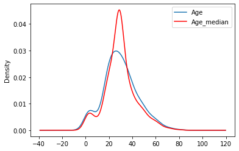

```python
# we can see that the distribution has changed slightly with now more values accumulating towards the median
fig = plt.figure()
ax = fig.add_subplot(111)
X_train['Age'].plot(kind='kde', ax=ax)
X_train.Age_median.plot(kind='kde', ax=ax, color='red')
#X_train.Age_random.plot(kind='kde', ax=ax, color='green')
lines, labels = ax.get_legend_handles_labels()
ax.legend(lines, labels, loc='best')
```

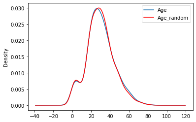

```python
# we can see that the distribution has changed slightly with now more values accumulating towards the median
fig = plt.figure()
ax = fig.add_subplot(111)
X_train['Age'].plot(kind='kde', ax=ax)
X_train.Age_random.plot(kind='kde', ax=ax, color='red')
lines, labels = ax.get_legend_handles_labels()
ax.legend(lines, labels, loc='best')
```

As mentioned above, the median imputation distorts the original distribution of the variable Age. The transformed variable shows more values around the median value. However, the distribution is kept intact if random value is imputed

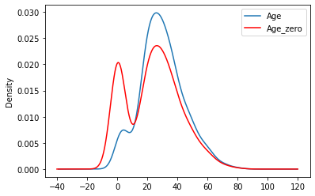

```python
# filling NA with zeroes creates a peak of population around 0, as expected
fig = plt.figure()
ax = fig.add_subplot(111)
X_train['Age'].plot(kind='kde', ax=ax)
X_train.Age_zero.plot(kind='kde', ax=ax, color='red')
lines, labels = ax.get_legend_handles_labels()
ax.legend(lines, labels, loc='best')
```

## Filling NA with 0s also distorts the distribution of the original variable, generating an accumulation of values around 0. We will see in the next lecture a method of NA imputation that preserves variable distribution.

# Adding a variable to capture NA

In previous lectures we studied how to replace missing values by mean/median imputation or by extracting a random sample of the variable for those instances where data is available, and using those values to replace the missing values. We also discussed that these 2 methods assume that the missing data are missing completely at random (MCAR).

So what if the data are not missing completely at random? By using this procedure, we would be missing important, predictive information.

How can we prevent that?

We can capture the importance of missingness by creating an additional variable indicating whether the data was missing for that observation (1) or not (0). The additional variable is a binary variable: it takes only the values 0 and 1, 0 indicating that a value was present for that observation, and 1 indicating that the value was missing for that observation.

### Advantages

- Easy to implement
- Captures the importance of missingess if there is one

### Disadvantages

- Expands the feature space

This method of imputation will add 1 variable per variable in the dataset with missing values. So if a dataset contains 10 features, and all of them have missing values, we will end up with a dataset with 20 features. The original features where we replaced the missing values by the mean/median (or random sampling), and additional 10 features, indicating for each of the variables, whether the value was missing or not.

This may not be a problem in datasets with tens to a few hundreds of variables, but if your original dataset contains thousands of variables, by creating an additional variable to indicate NA, you will end up with very big datasets.

In addition, data tends to be missing for the same observation on multiple variables, so it may also be the case, that many of your added variables will be actually similar to each other.

### Final note

Typically, mean/median imputation is done together with adding a variable to capture those observations where the data was missing , thus covering 2 angles: if the data was missing completely at random, this would be contemplated by the mean imputation, and if it wasn't this would be captured by the additional variable.

In addition, both methods are extremely straight forward to implement, and therefore are a top choice in data science competitions. See for example the winning solution of the KDD 2009 cup: "Winning the KDD Cup Orange Challenge with Ensemble Selection" (http://www.mtome.com/Publications/CiML/CiML-v3-book.pdf)

```python
X_train['Age_NA'] = np.where(X_train['Age'].isnull(), 1, 0)
X_test['Age_NA'] = np.where(X_test['Age'].isnull(), 1, 0)

X_train.head(20)
```

[output not shown]

# Arbitrary value imputation

Replacing the NA by artitrary values should be used when there are reasons to believe that the NA are not missing at random. In situations like this, we would not like to replace with the median or the mean, and therefore make the NA look like the majority of our observations.

Instead, we want to flag them. We want to capture the missingness somehow.

In previous lectures we saw 2 methods to do this:

1) adding an additional binary variable to indicate whether the value is missing (1) or not (0)

2) replacing the NA by a value at a far end of the distribution

Here, I suggest an alternative to option 2, which I have seen in several Kaggle competitions. It consists of replacing the NA by an arbitrary value. Any of your creation, but ideally different from the median/mean/mode, and not within the normal values of the variable.

The problem consists in deciding which arbitrary value to choose.

### Advantages

- Easy to implement
- Captures the importance of missingess if there is one

### Disadvantages

- Distorts the original distribution of the variable
- If missingess is not important, it may mask the predictive power of the original variable by distorting its distribution
- Hard to decide which value to use If the value is outside the distribution it may mask or create outliers

### Final note

When variables are captured by third parties, like credit agencies, they place arbitrary numbers already to signal this missingness. So if not common practice in data competitions, it is common practice in real life data collections.

```python
def impute_na_arbit(df, variable):
    df[variable+'_ten'] = df[variable].fillna(10)
    df[variable+'_hundred']= df[variable].fillna(100)
```

```python
impute_na_arbit(X_train, 'Age')
X_train.head(15)
```

|  | Survived | Age | Fare | Age_median | Age_zero | Age_mean | Age_random | Age_NA | Age_ten | Age_hundred |
| --- | --- | --- | --- | --- | --- | --- | --- | --- | --- | --- |
| 857 | 1 | 51.0 | 26.5500 | 51.0 | 51.0 | 51.000000 | 51.0 | 0 | 51.0 | 51.0 |
| 52 | 1 | 49.0 | 76.7292 | 49.0 | 49.0 | 49.000000 | 49.0 | 0 | 49.0 | 49.0 |
| 386 | 0 | 1.0 | 46.9000 | 1.0 | 1.0 | 1.000000 | 1.0 | 0 | 1.0 | 1.0 |
| 124 | 0 | 54.0 | 77.2875 | 54.0 | 54.0 | 54.000000 | 54.0 | 0 | 54.0 | 54.0 |
| 578 | 0 | NaN | 14.4583 | 29.0 | 0.0 | 29.915339 | 16.0 | 1 | 10.0 | 100.0 |
| 549 | 1 | 8.0 | 36.7500 | 8.0 | 8.0 | 8.000000 | 8.0 | 0 | 8.0 | 8.0 |
| 118 | 0 | 24.0 | 247.5208 | 24.0 | 24.0 | 24.000000 | 24.0 | 0 | 24.0 | 24.0 |
| 12 | 0 | 20.0 | 8.0500 | 20.0 | 20.0 | 20.000000 | 20.0 | 0 | 20.0 | 20.0 |
| 157 | 0 | 30.0 | 8.0500 | 30.0 | 30.0 | 30.000000 | 30.0 | 0 | 30.0 | 30.0 |
| 127 | 1 | 24.0 | 7.1417 | 24.0 | 24.0 | 24.000000 | 24.0 | 0 | 24.0 | 24.0 |
| 653 | 1 | NaN | 7.8292 | 29.0 | 0.0 | 29.915339 | 32.0 | 1 | 10.0 | 100.0 |
| 235 | 0 | NaN | 7.5500 | 29.0 | 0.0 | 29.915339 | 34.0 | 1 | 10.0 | 100.0 |
| 785 | 0 | 25.0 | 7.2500 | 25.0 | 25.0 | 25.000000 | 25.0 | 0 | 25.0 | 25.0 |
| 241 | 1 | NaN | 15.5000 | 29.0 | 0.0 | 29.915339 | 8.0 | 1 | 10.0 | 100.0 |
| 351 | 0 | NaN | 35.0000 | 29.0 | 0.0 | 29.915339 | 1.0 | 1 | 10.0 | 100.0 |

```python
## Lets revisit the distribution
print('Original Standard Deviation: ', X_train['Age'].std())
print('Standard Deviation after median imputation: ', X_train['Age_median'].std())
print('Standard Deviation after zero imputation: ', X_train['Age_zero'].std())
print('Standard Deviation after random imputation with ten: ', X_train['Age_ten'].std())
print('Standard Deviation after random imputation with hundred: ', X_train['Age_hundred'].std())
```

```
Original Standard Deviation:  14.506993804588443
Standard Deviation after median imputation:  13.024746215318798
Standard Deviation after zero imputation:  17.60095360447329
Standard Deviation after random imputation with ten:  15.221150495134205
Standard Deviation after random imputation with hundred:  30.650484585573828
```

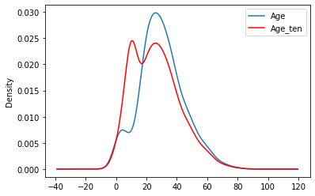

```python
# filling NA with ten's creates a peak of population around 0, as expected
fig = plt.figure()
ax = fig.add_subplot(111)
X_train['Age'].plot(kind='kde', ax=ax)
X_train.Age_ten.plot(kind='kde', ax=ax, color='red')
lines, labels = ax.get_legend_handles_labels()
ax.legend(lines, labels, loc='best')
```

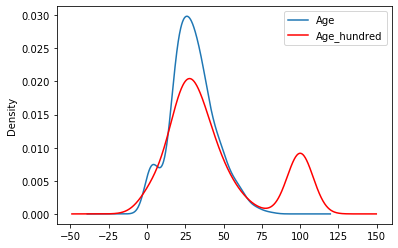

```python
# filling NA with hundred's creates a peak of population around 0, as expected
fig = plt.figure()
ax = fig.add_subplot(111)
X_train['Age'].plot(kind='kde', ax=ax)
X_train.Age_hundred.plot(kind='kde', ax=ax, color='red')
lines, labels = ax.get_legend_handles_labels()
ax.legend(lines, labels, loc='best')
```

# End of the distribution imputation

On occasions, one has reasons to suspect that missing values are not missing at random. And if the value is missing, there has to be a reason for it. Therefore, we would like to capture this information. We can replace the NA, by values that are at the far end of the distribution of the variable.

The rationale is that if the value is missing, it has to be for a reason, therefore, we would not like to replace missing values for the mean and make that observation look like the majority of our observations. Instead, we want to flag that observation as different, and therefore we assign a value that is at the tail of the distribution, where observations are rarely represented in the population.

### Advantages

- Easy to implement
- Captures the importance of missingess if there is one

### Disadvantages

- Distorts the original distribution of the variable
- If missingess is not important, it may mask the predictive power of the original variable by distorting its distribution
- If the number of NA is big, it will mask true outliers in the distribution
- If the number of NA is small, the replaced NA may be considered an outlier and pre-processed in a subsequent step of feature engineering

```python
def impute_na(df, variable, median, extreme):
    df[variable+'_far_end'] = df[variable].fillna(extreme)
    df[variable].fillna(median, inplace=True)
```

```python
# let's replace the NA with the median value in the training and testing sets
impute_na(X_train, 'Age', X_train.Age.median(), X_train.Age.mean()+3*X_train.Age.std())
impute_na(X_test, 'Age', X_train.Age.median(), X_train.Age.mean()+3*X_train.Age.std())

X_train.head(20)
```

|  | Survived | Age | Fare | Age_median | Age_zero | Age_mean | Age_random | Age_NA | Age_ten | Age_hundred | Age_far_end |
| --- | --- | --- | --- | --- | --- | --- | --- | --- | --- | --- | --- |
| 857 | 1 | 51.0 | 26.5500 | 51.0 | 51.0 | 51.000000 | 51.0 | 0 | 51.0 | 51.0 | 51.00000 |
| 52 | 1 | 49.0 | 76.7292 | 49.0 | 49.0 | 49.000000 | 49.0 | 0 | 49.0 | 49.0 | 49.00000 |
| 386 | 0 | 1.0 | 46.9000 | 1.0 | 1.0 | 1.000000 | 1.0 | 0 | 1.0 | 1.0 | 1.00000 |
| 124 | 0 | 54.0 | 77.2875 | 54.0 | 54.0 | 54.000000 | 54.0 | 0 | 54.0 | 54.0 | 54.00000 |
| 578 | 0 | 29.0 | 14.4583 | 29.0 | 0.0 | 29.915339 | 16.0 | 1 | 10.0 | 100.0 | 73.43632 |
| 549 | 1 | 8.0 | 36.7500 | 8.0 | 8.0 | 8.000000 | 8.0 | 0 | 8.0 | 8.0 | 8.00000 |
| 118 | 0 | 24.0 | 247.5208 | 24.0 | 24.0 | 24.000000 | 24.0 | 0 | 24.0 | 24.0 | 24.00000 |
| 12 | 0 | 20.0 | 8.0500 | 20.0 | 20.0 | 20.000000 | 20.0 | 0 | 20.0 | 20.0 | 20.00000 |
| 157 | 0 | 30.0 | 8.0500 | 30.0 | 30.0 | 30.000000 | 30.0 | 0 | 30.0 | 30.0 | 30.00000 |
| 127 | 1 | 24.0 | 7.1417 | 24.0 | 24.0 | 24.000000 | 24.0 | 0 | 24.0 | 24.0 | 24.00000 |
| 653 | 1 | 29.0 | 7.8292 | 29.0 | 0.0 | 29.915339 | 32.0 | 1 | 10.0 | 100.0 | 73.43632 |
| 235 | 0 | 29.0 | 7.5500 | 29.0 | 0.0 | 29.915339 | 34.0 | 1 | 10.0 | 100.0 | 73.43632 |
| 785 | 0 | 25.0 | 7.2500 | 25.0 | 25.0 | 25.000000 | 25.0 | 0 | 25.0 | 25.0 | 25.00000 |
| 241 | 1 | 29.0 | 15.5000 | 29.0 | 0.0 | 29.915339 | 8.0 | 1 | 10.0 | 100.0 | 73.43632 |
| 351 | 0 | 29.0 | 35.0000 | 29.0 | 0.0 | 29.915339 | 1.0 | 1 | 10.0 | 100.0 | 73.43632 |
| 862 | 1 | 48.0 | 25.9292 | 48.0 | 48.0 | 48.000000 | 48.0 | 0 | 48.0 | 48.0 | 48.00000 |
| 851 | 0 | 74.0 | 7.7750 | 74.0 | 74.0 | 74.000000 | 74.0 | 0 | 74.0 | 74.0 | 74.00000 |
| 753 | 0 | 23.0 | 7.8958 | 23.0 | 23.0 | 23.000000 | 23.0 | 0 | 23.0 | 23.0 | 23.00000 |
| 532 | 0 | 17.0 | 7.2292 | 17.0 | 17.0 | 17.000000 | 17.0 | 0 | 17.0 | 17.0 | 17.00000 |
| 485 | 0 | 29.0 | 25.4667 | 29.0 | 0.0 | 29.915339 | 34.0 | 1 | 10.0 | 100.0 | 73.43632 |

```python
## Lets revisit the distribution
print('Original Standard Deviation: ', X_train['Age'].std())
print('Standard Deviation after median imputation: ', X_train['Age_median'].std())
print('Standard Deviation after zero imputation: ', X_train['Age_zero'].std())
print('Standard Deviation after random imputation with ten: ', X_train['Age_ten'].std())
print('Standard Deviation after random imputation with hundred: ', X_train['Age_hundred'].std())
print('Standard Deviation after random imputation with extreme values: ', X_train['Age_far_end'].std())
```

```
Original Standard Deviation:  13.024746215318798
Standard Deviation after median imputation:  13.024746215318798
Standard Deviation after zero imputation:  17.60095360447329
Standard Deviation after random imputation with ten:  15.221150495134205
Standard Deviation after random imputation with hundred:  30.650484585573828
Standard Deviation after random imputation with extreme values:  21.596555047537485
```